# Pakistan Solar Panel Prices and Global Polysilicon: An ARIMAX Analysis

## 4 Stationarity tests

Both series look non-stationary in levels. The battery below runs ADF, KPSS, and Phillips-Perron on levels and first differences.

```r
unit_root_battery <- function(series, name) {
  cat("\n===", name, "===\n")
  cat("ADF (level):  p =", round(adf.test(series)$p.value, 4), "\n")
  cat("KPSS (level): p =", round(kpss.test(series, "Level")$p.value, 4), "\n")
  cat("PP  (level):  p =", round(pp.test(series)$p.value, 4), "\n")
  cat("ADF (1st diff): p =", round(adf.test(diff(series))$p.value, 4), "\n")
}
unit_root_battery(y, "Log Panel Price")
```

```
=== Log Panel Price ===
ADF (level):  p = 0.7363
```

```
KPSS (level): p = 0.01
PP  (level):  p = 0.846
ADF (1st diff): p = 0.0238
```

```r
unit_root_battery(x, "Log Polysilicon Price")
```

```
=== Log Polysilicon Price ===
ADF (level):  p = 0.8965
KPSS (level): p = 0.0102
PP  (level):  p = 0.9251
ADF (1st diff): p = 0.1541
```

```r
cat("\nndiffs(y) =", ndiffs(y), " | ndiffs(x) =", ndiffs(x), "\n")
```

```
ndiffs(y) = 1  | ndiffs(x) = 1
```

## 5 ACF / PACF identification

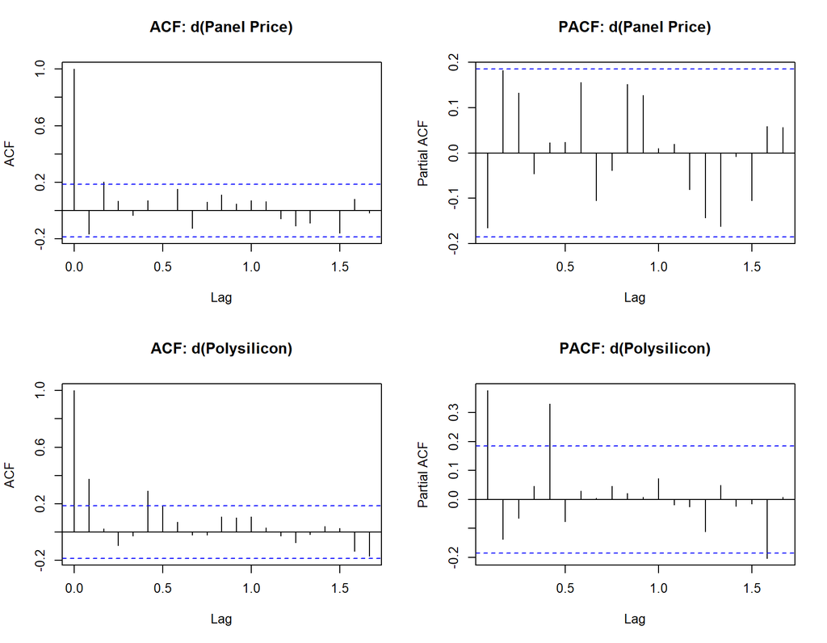

ACF/PACF of first-differenced series

```r
par(mfrow = c(2, 2))
acf(diff(y),  main = "ACF: d(Panel Price)")
pacf(diff(y), main = "PACF: d(Panel Price)")
acf(diff(x),  main = "ACF: d(Polysilicon)")
pacf(diff(x), main = "PACF: d(Polysilicon)")
```

```r
par(mfrow = c(1, 1))
```

## 6 Cointegration

```r
eg_reg <- lm(y ~ x)
summary(eg_reg)
```

```
Call:
lm(formula = y ~ x)

Residuals:
     Min       1Q   Median       3Q      Max
-0.47923 -0.23939 -0.01016  0.21182  0.52348

Coefficients:
            Estimate Std. Error t value Pr(>|t|)
(Intercept) -2.75081    0.08884  -30.96   <2e-16 ***
x            0.47990    0.03493   13.74   <2e-16 ***
---
Signif. codes:  0 '***' 0.001 '**' 0.01 '*' 0.05 '.' 0.1 ' ' 1

Residual standard error: 0.263 on 111 degrees of freedom
Multiple R-squared:  0.6297,    Adjusted R-squared:  0.6263
F-statistic: 188.7 on 1 and 111 DF,  p-value: < 2.2e-16
```

```r
eg_resid <- residuals(eg_reg)
eg_adf <- ur.df(eg_resid, type = "none", selectlags = "AIC")
cat("\nEngle-Granger step 2 (residual ADF), tau =", round(eg_adf@teststat[1], 3),
    " | 5% crit =", eg_adf@cval[1, "5pct"], "\n")
```

```
Engle-Granger step 2 (residual ADF), tau = -1.975  | 5% crit = -1.95
```

```r
jo <- ca.jo(cbind(y, x), type = "trace", ecdet = "const", K = 2)
summary(jo)
```

```
######################
# Johansen-Procedure #
######################

Test type: trace statistic , without linear trend and constant in cointegration

Eigenvalues (lambda):
[1] 4.429505e-02 4.028875e-02 4.163336e-17

Values of teststatistic and critical values of test:

         test 10pct  5pct  1pct
r <= 1 | 4.56  7.52  9.24 12.97
r = 0  | 9.59 17.85 19.96 24.60

Eigenvectors, normalised to first column:
(These are the cointegration relations)

               y.l2       x.l2   constant
y.l2      1.0000000  1.0000000 1.00000000
x.l2     -0.5163466 -0.9587116 0.47322825
constant  2.9994605  3.4414821 0.07950448

Weights W:
(This is the loading matrix)

           y.l2       x.l2      constant
y.d -0.02888688 0.01379029 -2.245622e-17
x.d  0.05266642 0.02838822  3.825622e-17
```

**WarningSample-size caveat**

With n = 113 monthly observations, the Johansen and Engle-Granger tests have limited power. Read the cointegration result as indicative and re-estimate as more months of data accrue.

## 7 Granger causality

```r
cat("Does polysilicon Granger-cause panel price?\n")
```

```
Does polysilicon Granger-cause panel price?
```

```r
print(grangertest(y ~ x, order = 3))
```

```
Granger causality test

Model 1: y ~ Lags(y, 1:3) + Lags(x, 1:3)
Model 2: y ~ Lags(y, 1:3)
  Res.Df Df      F Pr(>F)
1    103
2    106 -3 0.5479 0.6507
```

```r
cat("\nDoes panel price Granger-cause polysilicon?\n")
```

```
Does panel price Granger-cause polysilicon?
```

```r
print(grangertest(x ~ y, order = 3))
```

```
Granger causality test

Model 1: x ~ Lags(x, 1:3) + Lags(y, 1:3)
Model 2: x ~ Lags(x, 1:3)
  Res.Df Df     F   Pr(>F)
1    103
2    106 -3 4.583 0.004708 **
---
Signif. codes:  0 '***' 0.001 '**' 0.01 '*' 0.05 '.' 0.1 ' ' 1
```

## 8 Model estimation and out-of-sample accuracy

The last 13 months are held out; ARIMA, ARIMAX, and a naive random-walk benchmark are compared on RMSE, MAE, and MAPE.

```r
train_h  <- 100
y_train  <- window(y, end = time(y)[train_h])
x_train  <- window(x, end = time(x)[train_h])
y_test   <- window(y, start = time(y)[train_h + 1])
x_test   <- window(x, start = time(x)[train_h + 1])

m_arima  <- auto.arima(y_train, stepwise = FALSE, approximation = FALSE)
m_arimax <- auto.arima(y_train, xreg = x_train, stepwise = FALSE, approximation = FALSE)

summary(m_arima)
```

```
Series: y_train
ARIMA(0,1,0)(0,0,2)[12] with drift

Coefficients:
       sma1    sma2    drift
      0.142  0.2932  -0.0145
s.e.  0.104  0.1249   0.0076

sigma^2 = 0.003246:  log likelihood = 143.55
AIC=-279.1   AICc=-278.68   BIC=-268.72

Training set error measures:
                        ME       RMSE        MAE        MPE     MAPE      MASE
Training set -2.328004e-05 0.05582143 0.03535319 -0.1112613 2.349967 0.1578428
                    ACF1
Training set -0.08212039
```

```r
summary(m_arimax)
```

```
Series: y_train
Regression with ARIMA(1,1,0)(0,0,2)[12] errors

Coefficients:
          ar1    sma1    sma2    drift    xreg
      -0.1588  0.1308  0.3371  -0.0131  0.0875
s.e.   0.1022  0.1032  0.1323   0.0066  0.0386

sigma^2 = 0.00312:  log likelihood = 146.19
AIC=-280.37   AICc=-279.46   BIC=-264.8

Training set error measures:
                        ME       RMSE        MAE        MPE     MAPE      MASE
Training set -5.372398e-06 0.05415472 0.03418746 -0.1111063 2.290322 0.1526381
                    ACF1
Training set 0.007790024
```

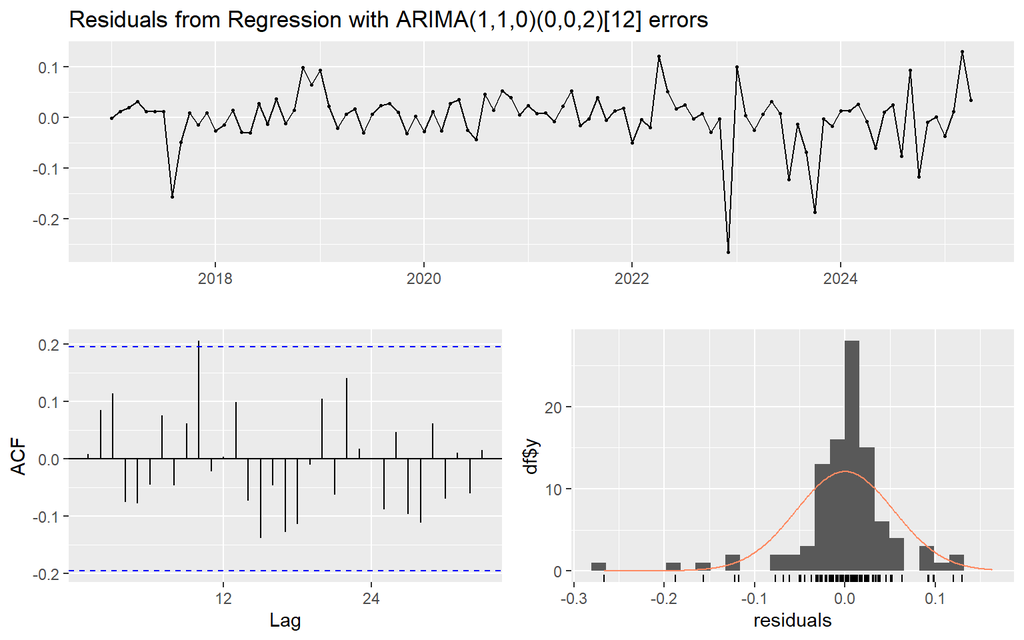

Residual diagnostics: ARIMAX model

```
    Ljung-Box test

data:  Residuals from Regression with ARIMA(1,1,0)(0,0,2)[12] errors
Q* = 19.171, df = 17, p-value = 0.3188

Model df: 3.   Total lags used: 20
```

```r
checkresiduals(m_arimax)
```

```r
cat("Jarque-Bera (ARIMAX resid): p =",
    round(jarque.bera.test(residuals(m_arimax))$p.value, 4), "\n")
```

```
Jarque-Bera (ARIMAX resid): p = 0
```

```r
cat("ARCH-LM (ARIMAX resid, lag 6):\n")
```

```
ARCH-LM (ARIMAX resid, lag 6):
```

```r
print(Box.test(residuals(m_arimax)^2, lag = 6, type = "Ljung-Box"))
```

```
    Box-Ljung test

data:  residuals(m_arimax)^2
X-squared = 2.0366, df = 6, p-value = 0.9163
```

```r
h <- length(y_test)
f_arima  <- forecast(m_arima,  h = h)
f_arimax <- forecast(m_arimax, xreg = x_test, h = h)   # oracle: actual future polysilicon
f_naive  <- naive(y_train, h = h)

acc_tbl <- rbind(
  ARIMA  = accuracy(f_arima,  y_test)["Test set", c("RMSE", "MAE", "MAPE")],
  ARIMAX = accuracy(f_arimax, y_test)["Test set", c("RMSE", "MAE", "MAPE")],
  Naive  = accuracy(f_naive,  y_test)["Test set", c("RMSE", "MAE", "MAPE")]
)
knitr::kable(round(acc_tbl, 4), caption = "Out-of-sample accuracy, 13-month holdout")
```

Out-of-sample accuracy, 13-month holdout

|  | RMSE | MAE | MAPE |
| --- | --- | --- | --- |
| ARIMA | 0.2819 | 0.2388 | 10.7452 |
| ARIMAX | 0.2487 | 0.2052 | 9.2516 |
| Naive | 0.0900 | 0.0585 | 2.6350 |

```r
cv_arima <- tsCV(y, function(z, h) forecast(auto.arima(z), h = h), h = 1)
rmse_cv  <- round(sqrt(mean(cv_arima^2, na.rm = TRUE)), 4)
cat("Rolling 1-step CV RMSE (ARIMA):", rmse_cv, "\n")
```

```
Rolling 1-step CV RMSE (ARIMA): 0.0642
```